# Bikes

Banta Jabbi

2024-10-30

## INSTALLING & LOADING PACKAGES AND DATA

```r
library(tidyverse)
```

```r
library(readxl)
library(ggplot2)
library(ggrepel)
library(rpart)
library(rpart.plot)
library(rattle)
```

Loading the data and checking its content and types.

```r
bikes_data <- read.csv("C:\\Users\\User\\Downloads\\bikes_1.csv")
head(bikes_data)
```

```
##      ID Marital_Status Gender     Income Children       Education
## 1 12496              M      F $40,000.00        1       Bachelors
## 2 24107              M      M $30,000.00        3 Partial College
## 3 14177              M      M $80,000.00        5 Partial College
## 4 24381              S      M $70,000.00        0       Bachelors
## 5 25597              S      M $30,000.00        0       Bachelors
## 6 13507              M      F $10,000.00        2 Partial College
##       Occupation Home_Owner Cars Commute.Distance  Region Age Purchased_Bike
## 1 Skilled Manual        Yes    0        0-1 Miles  Europe  42             No
## 2       Clerical        Yes    1        0-1 Miles  Europe  43             No
## 3   Professional         No    2        2-5 Miles  Europe  60             No
## 4   Professional        Yes    1       5-10 Miles Pacific  41            Yes
## 5       Clerical         No    0        0-1 Miles  Europe  36            Yes
## 6         Manual        Yes    0        1-2 Miles  Europe  50             No
```

```r
summary(bikes_data)
```

```
##        ID        Marital_Status        Gender             Income
##  Min.   :11000   Length:1026        Length:1026        Length:1026
##  1st Qu.:15305   Class :character   Class :character   Class :character
##  Median :19744   Mode  :character   Mode  :character   Mode  :character
##  Mean   :19969
##  3rd Qu.:24458
##  Max.   :29447
##     Children      Education          Occupation         Home_Owner
##  Min.   :0.000   Length:1026        Length:1026        Length:1026
##  1st Qu.:0.000   Class :character   Class :character   Class :character
##  Median :2.000   Mode  :character   Mode  :character   Mode  :character
##  Mean   :1.893
##  3rd Qu.:3.000
##  Max.   :5.000
##       Cars       Commute.Distance      Region               Age
##  Min.   :0.000   Length:1026        Length:1026        Min.   :25.00
##  1st Qu.:1.000   Class :character   Class :character   1st Qu.:35.00
##  Median :1.000   Mode  :character   Mode  :character   Median :43.00
##  Mean   :1.438                                         Mean   :44.14
##  3rd Qu.:2.000                                         3rd Qu.:52.00
##  Max.   :4.000                                         Max.   :89.00
##  Purchased_Bike
##  Length:1026
##  Class :character
##  Mode  :character
##
##
##
```

Counting the amount of rows/records in the original dataset.

```r
count(bikes_data)
```

```
##      n
## 1 1026
```

Counting the unique values.

```r
count(bikes_data %>% distinct())
```

```
##      n
## 1 1000
```

## CLEANING THE DATA

Creating a new column with the help of the case_when function.

```r
bikes_data <- bikes_data %>%
  distinct() %>%
  mutate(Age_Category = case_when(
    Age <= 35 ~ "Young",
    Age >35 & Age <= 50 ~ "Middle Age",
    Age > 50 ~ "Old"))
```

Dropping the age column

```r
bikes_data <- bikes_data %>%
  select(!Age)
```

Updating columns.

```r
bikes_data <- bikes_data%>%
  mutate(Commute.Distance = replace( Commute.Distance,Commute.Distance == "10+ Miles","More than 10 Miles"))%>%
  mutate(Marital_Status = replace(Marital_Status, Marital_Status == "S", "Single"))%>%
  mutate(Marital_Status = replace(Marital_Status, Marital_Status == "M", "Married"))%>%
  mutate(Gender = replace(Gender, Gender == "M", "Male"))%>%
  mutate(Gender = replace(Gender, Gender == "F", "Female"))
```

```r
bikes_data
```

```
##         ID Marital_Status Gender      Income Children           Education
## 1    12496        Married Female  $40,000.00        1           Bachelors
## 2    24107        Married   Male  $30,000.00        3     Partial College
## 3    14177        Married   Male  $80,000.00        5     Partial College
## 4    24381         Single   Male  $70,000.00        0           Bachelors
## 5    25597         Single   Male  $30,000.00        0           Bachelors
## 6    13507        Married Female  $10,000.00        2     Partial College
## 7    27974         Single   Male $160,000.00        2         High School
## 8    19364        Married   Male  $40,000.00        1           Bachelors
## 9    22155        Married   Male  $20,000.00        2 Partial High School
## 10   19280        Married   Male $120,000.00        2     Partial College
## 11   22173        Married Female  $30,000.00        3         High School
## 12   12697         Single Female  $90,000.00        0           Bachelors
## 13   11434        Married   Male $170,000.00        5     Partial College
## 14   25323        Married   Male  $40,000.00        2     Partial College
```

[output cut: 2988 more lines]

## VISUALISING THE DATA

Using ggplot, to create a bar chart to discover who is more inclined to buy bikes: single or married.

```r
marital_status <- bikes_data%>%
  select(Marital_Status, Purchased_Bike)%>%
  group_by(Marital_Status, Purchased_Bike)%>%
  summarise(n = n(), .groups = "drop")
marital_status
```

```
## # A tibble: 4 × 3
##   Marital_Status Purchased_Bike     n
##   <chr>          <chr>          <int>
## 1 Married        No               307
## 2 Married        Yes              231
## 3 Single         No               212
## 4 Single         Yes              250
```

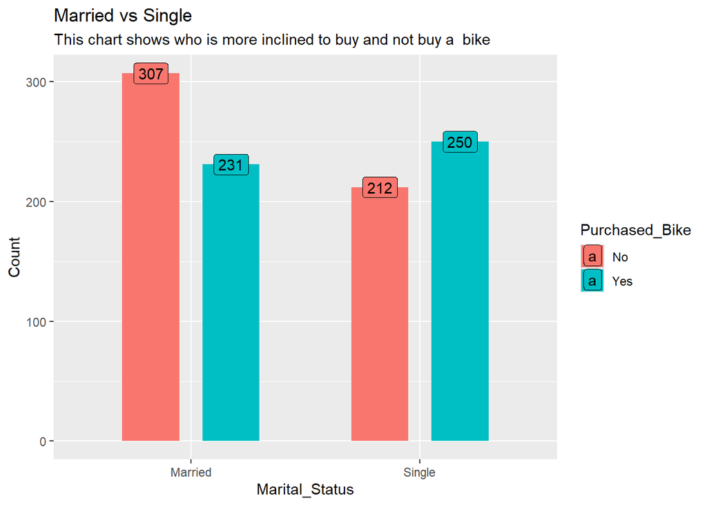

```r
ggplot(marital_status, aes(x = Marital_Status, y = n, label = n, fill = Purchased_Bike))+
  geom_bar(stat = "identity", position = position_dodge(.7), width = .5)+
  #geom_text()+
  geom_label(position = position_dodge2(width = .7))+
  labs(title = "Married vs Single",
       subtitle = "This chart shows who is more inclined to buy and not buy a  bike",
       y = "Count")
```

Using ggplot, to create a bar chart to discover who is more inclined to buy bikes: men or women.

```r
genders <- bikes_data%>%
  select(Gender, Purchased_Bike)%>%
  group_by(Gender, Purchased_Bike)%>%
  summarise(n = n(), .groups = "drop")

genders
```

```
## # A tibble: 4 × 3
##   Gender Purchased_Bike     n
##   <chr>  <chr>          <int>
## 1 Female No               250
## 2 Female Yes              239
## 3 Male   No               269
## 4 Male   Yes              242
```

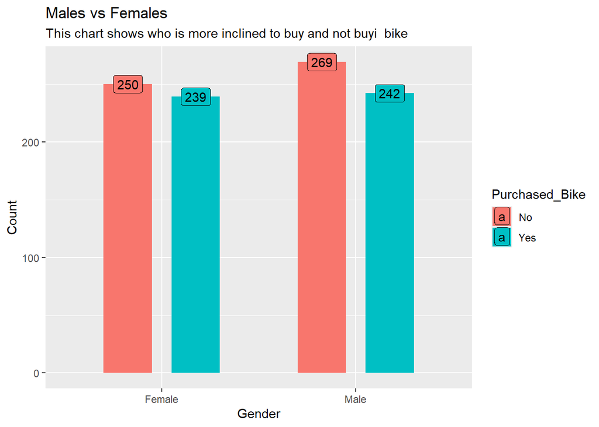

```r
ggplot(genders, aes(x = Gender, y = n, label = n, fill = Purchased_Bike))+
  geom_bar(stat = "identity", position = position_dodge(.7), width = .5)+
  geom_label(position = position_dodge2(width = .7))+
  labs(title = "Males vs Females", subtitle = "This chart shows who is more inclined to buy and not buyi  bike", y = "Count")
```

Using ggplot, to create a bar chart to discover who is more inclined to buy bikes: men(between Single and Married) or women(Single and Married).

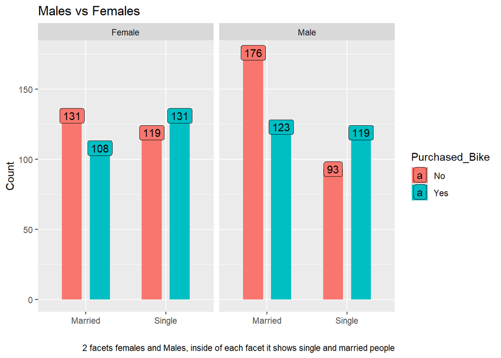

```r
gender_maritalStatus <- bikes_data%>%
  select(Gender, Marital_Status, Purchased_Bike)%>%
  group_by(Gender, Marital_Status, Purchased_Bike)%>%
  summarise(count = n(), .groups = "drop")

ggplot(gender_maritalStatus, aes(x = Marital_Status, y = count, fill = Purchased_Bike, label = count))+
  geom_bar(stat = "identity", position = position_dodge(width = .7), width = .5)+
  geom_label(position = position_dodge(width = .7))+
  facet_wrap(~Gender)+
  labs(title = "Males vs Females", caption = "2 facets females and Males, inside of each facet it shows single and married people", x = "" ,y = "Count")
```

Using ggplot, create a bar chart to show the total number of participants, in each occupation category.

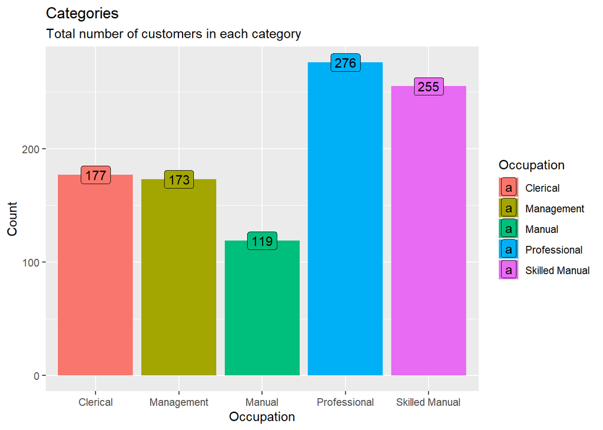

```r
total_participants_Categories <- bikes_data%>%
  select(Occupation)%>%
  group_by(Occupation)%>%
  summarise(total = n(), .groups = "drop")

ggplot(total_participants_Categories, aes(x = Occupation, y = total, label = total, fill = Occupation))+
  geom_bar(stat = "identity")+
  geom_label()+
  labs(title = "Categories", subtitle = "Total number of customers in each category", y = "Count")
```

Using ggplot, create a bar chart to discover the occupations with more than 10 miles of commute distance, as this suggest people with more than 10 miles of distance are less willing to buy a bike.

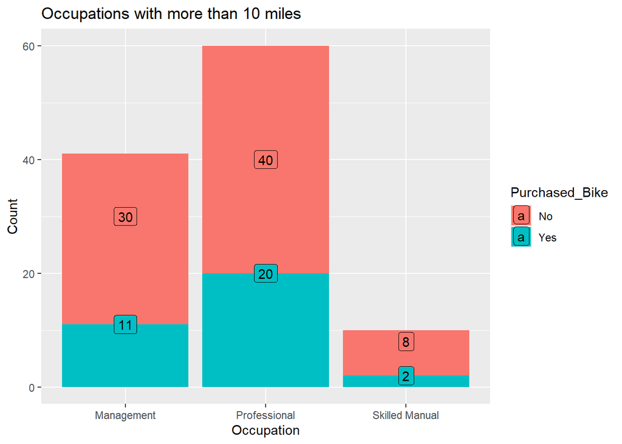

```r
profession <- bikes_data %>%
  group_by(Occupation, Commute.Distance, Purchased_Bike)%>%
  summarise(n = n(), .groups = "drop")%>%
  filter(Commute.Distance == "More than 10 Miles")

ggplot(profession, aes(x = Occupation, y = n, label = n, fill = Purchased_Bike))+
  geom_bar(stat = "identity")+
  geom_text()+
  labs(title = "Occupations with more than 10 miles", y = "Count")+
  geom_label()
```

Using ggplot, create a line chart to discover purchases, based on commute distance.

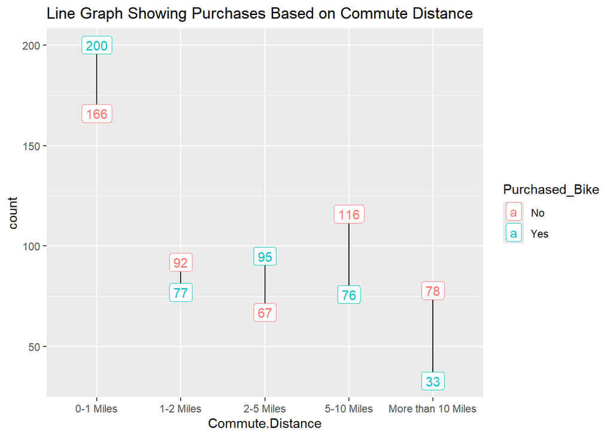

```r
bikes_data%>%
  select(Commute.Distance, Purchased_Bike)%>%
  group_by(Commute.Distance, Purchased_Bike)%>%
  summarise(count = n(), .groups = "drop")%>%
  ggplot(aes(x = Commute.Distance, y = count, color = Purchased_Bike, label = count ))+
  geom_line(linetype = "solid", color = "black")+
  geom_label()+
  labs(title = "Line Graph Showing Purchases Based on Commute Distance")
```

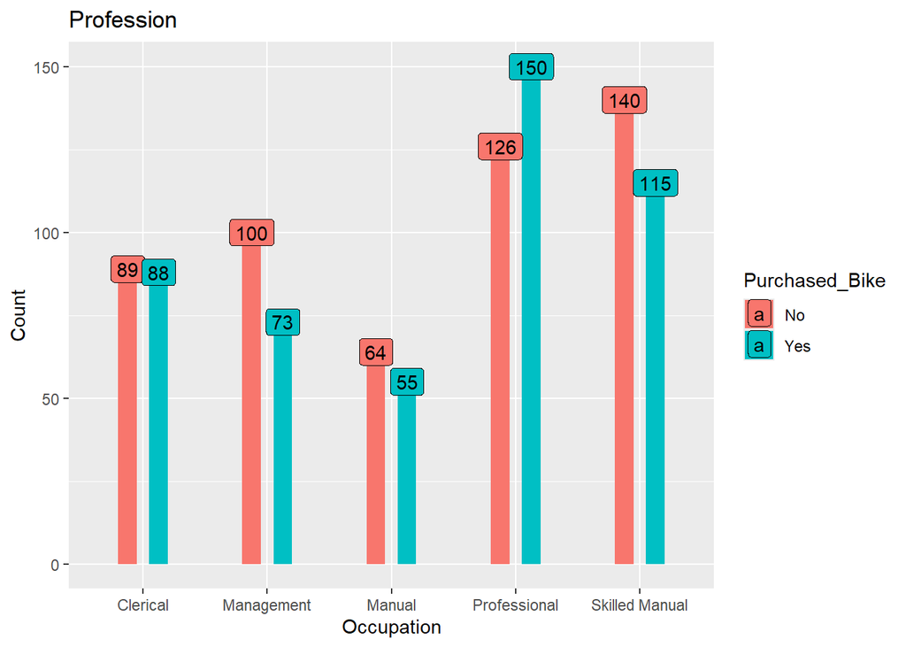

```r
profession_buying_bikes <- bikes_data%>%
  select(Occupation, Purchased_Bike)%>%
  group_by(Occupation, Purchased_Bike)%>%
  summarise(count = n(), .groups = "drop")

ggplot(profession_buying_bikes, aes(x = Occupation, y = count, fill = Purchased_Bike, label = count))+
  geom_bar(stat = "identity", position = position_dodge(0.5), width = 0.3)+
 ## geom_text_repel(color = "#FFFFFF")+
  geom_label(position = position_dodge(0.5))+
  labs(title = "Profession", y = "Count")
```

using ggplot, to find trends about the education and purchases.

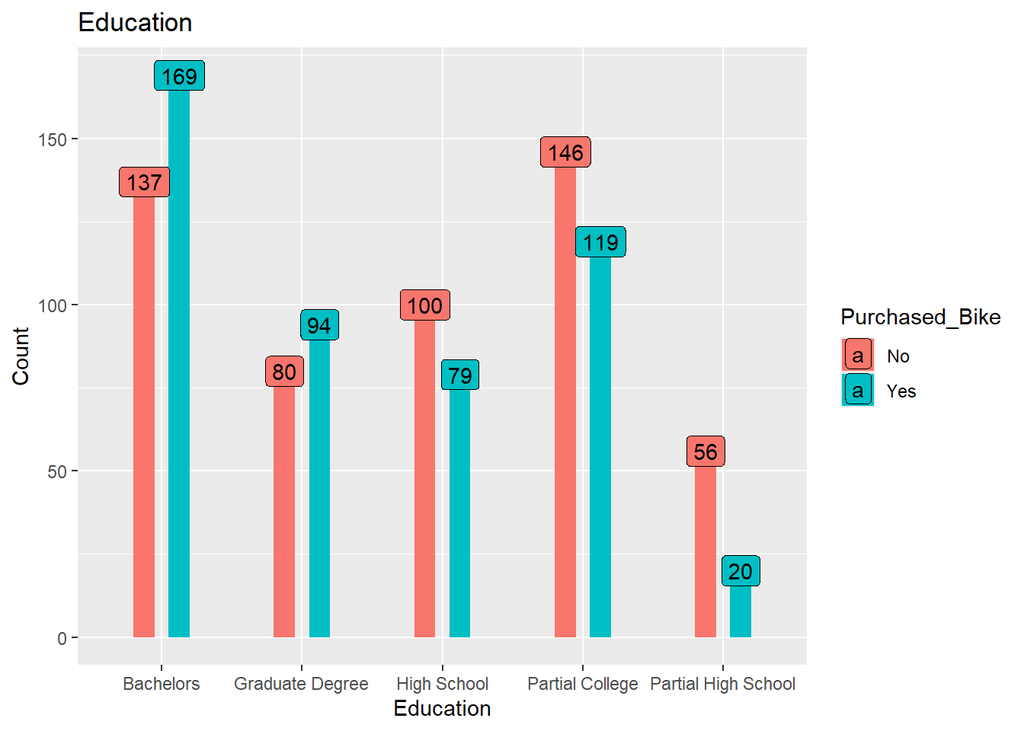

```r
education_buying_bikes <- bikes_data%>%
  select(Education, Purchased_Bike)%>%
  group_by(Education, Purchased_Bike)%>%
  summarise(count = n(), .groups = "drop")

ggplot(education_buying_bikes, aes(x = Education, y = count, fill = Purchased_Bike, label = count))+
  geom_bar(stat = "identity", position = position_dodge(0.5), width = 0.3)+
  geom_label(position = position_dodge(0.5))+
  labs(title = "Education", y = "Count")
```

using ggplot, to find trends about the region and purchases.

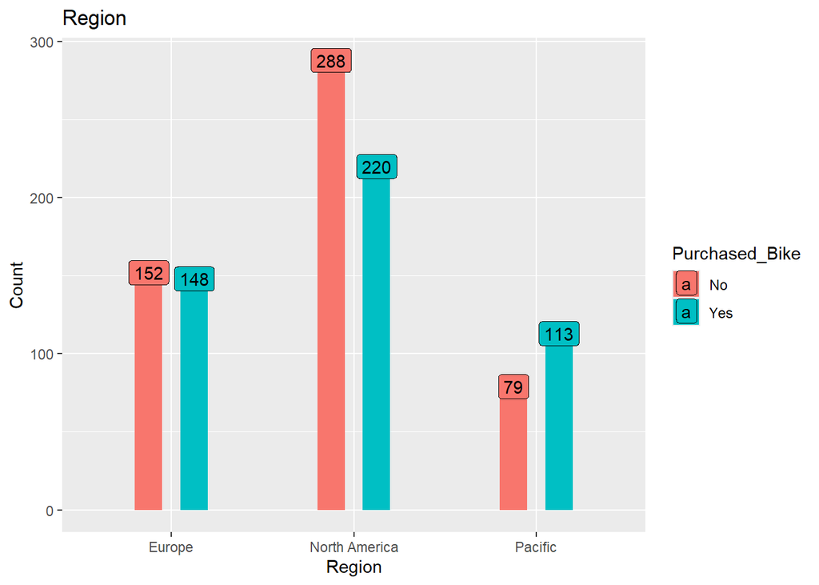

```r
region_buying_bikes <- bikes_data%>%
  select(Region, Purchased_Bike)%>%
  group_by(Region, Purchased_Bike)%>%
  summarise(count = n(), .groups = "drop")

ggplot(region_buying_bikes, aes(x = Region, y = count, fill = Purchased_Bike, label = count))+
  geom_bar(stat = "identity", position = position_dodge(0.5), width = 0.3)+
  geom_label(position = position_dodge(0.5))+
  labs(title = "Region", y = "Count")
```

using ggplot, to find trends about the Age Categories and purchases.

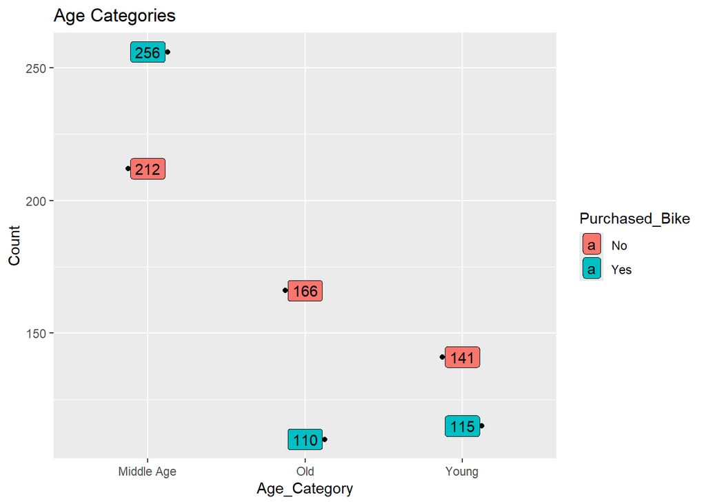

```r
agesVSbuying <-  bikes_data%>%
  select(Age_Category, Purchased_Bike)%>%
  group_by(Age_Category, Purchased_Bike)%>%
  summarise(count = n(), .groups = "drop")

ggplot(agesVSbuying, aes(x = Age_Category, y = count, fill = Purchased_Bike, label = count))+
  geom_point(stat = "identity", position = position_dodge(0.5))+
  ## geom_text_repel(color = "#FFFFFF")+
  #geom_label(position = position_dodge(0.5))
  geom_label()+
  labs(title = "Age Categories", y = "Count")
```

## CREATING A DECISON TREEMODEL

Creating a sample

```r
set.seed(1)

sample <- sample(c(TRUE, FALSE), nrow(bikes_data), replace = TRUE, prob = c(0.7, 0.3))
train <- bikes_data[sample, ]
test <- bikes_data[!sample, ]
```

Creating the decision tree

```r
bikes_tree <- rpart(formula = Purchased_Bike ~ Gender + Marital_Status + Income + Children +
                      Home_Owner + Cars + Education + Occupation + Commute.Distance +
                      Region + Age_Category,
                    cp = 0.01,
                    maxdepth = 5,
                    data = train,
                    method = "class")
```

Using the cp functions

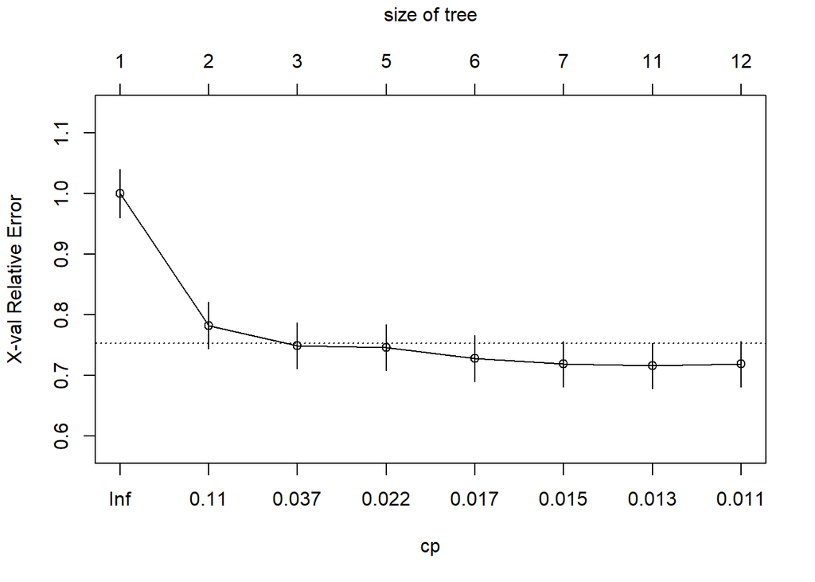

```r
plotcp(bikes_tree)
```

```r
printcp(bikes_tree)
```

```
##
## Classification tree:
## rpart(formula = Purchased_Bike ~ Gender + Marital_Status + Income +
##     Children + Home_Owner + Cars + Education + Occupation + Commute.Distance +
##     Region + Age_Category, data = train, method = "class", cp = 0.01,
##     maxdepth = 5)
##
## Variables actually used in tree construction:
## [1] Cars             Children         Commute.Distance Income
## [5] Marital_Status   Region
##
## Root node error: 331/696 = 0.47557
##
## n= 696
##
##         CP nsplit rel error  xerror     xstd
## 1 0.217523      0   1.00000 1.00000 0.039804
## 2 0.051360      1   0.78248 0.78248 0.038526
## 3 0.027190      2   0.73112 0.74924 0.038171
## 4 0.018127      4   0.67674 0.74622 0.038136
## 5 0.015106      5   0.65861 0.72810 0.037921
## 6 0.014350      6   0.64350 0.71903 0.037808
## 7 0.012085     10   0.58610 0.71601 0.037770
## 8 0.010000     11   0.57402 0.71903 0.037808
```

Checking misclassification error.

```r
sum(predict(bikes_tree, type = "class")!=train$Purchased_Bike) / nrow(train)
```

```
## [1] 0.2729885
```

Visualize decision tree

[figure not shown]

```r
fancyRpartPlot(bikes_tree)
```

predicting and binding the column to the bikes_tree dataset.

```r
predicted_purchase <- predict(bikes_tree, type = "class")
bind_tables <- cbind(train, predicted_purchase)
```

```r
bind_tables
```

```
##         ID Marital_Status Gender      Income Children           Education
## 1    12496        Married Female  $40,000.00        1           Bachelors
## 2    24107        Married   Male  $30,000.00        3     Partial College
## 3    14177        Married   Male  $80,000.00        5     Partial College
## 5    25597         Single   Male  $30,000.00        0           Bachelors
## 8    19364        Married   Male  $40,000.00        1           Bachelors
## 9    22155        Married   Male  $20,000.00        2 Partial High School
## 10   19280        Married   Male $120,000.00        2     Partial College
## 11   22173        Married Female  $30,000.00        3         High School
## 12   12697         Single Female  $90,000.00        0           Bachelors
## 13   11434        Married   Male $170,000.00        5     Partial College
## 14   25323        Married   Male  $40,000.00        2     Partial College
## 16   20870         Single Female  $10,000.00        2         High School
## 19   27183         Single   Male  $40,000.00        2     Partial College
## 22   21564         Single Female  $80,000.00        0           Bachelors
```

[output cut: 2076 more lines]

Testing the model with new data

```r
new_input <- predict(object = bikes_tree,
                     newdata = data.frame(
                       Gender = "Male", Marital_Status = "Married", Income = "$30,000.00", Children = 2,
                       Home_Owner = "No", Cars = 1, Education = "Bachelors",
                       Occupation = "Professional", Commute.Distance = "0-1 Miles",
                       Region = "North America", Age_Category = "Middle Age"),
                     type = "class")
```

```r
new_input
```

```
##   1
## Yes
## Levels: No Yes
```